# syntx (TVF, SyNGS, SyN) vs. ants.registration — Mindboggle-101 Cohort Benchmark

COHORT BENCHMARK COMPLETE **90 / 90 Subject Pairs (100.0%)** (40 intra-site, 50 inter-site) • **Random Pair Seed:** `20261112`

Elapsed: **1506.5 min**

**Generated:** 2026-11-15T05:44:47Z | **syntx:** `v6.37.0` (`eae7b794f9`, dirty=True) | **Hardware:** macOS-26.5.2-arm64-arm-64bit-Mach-O (24 CPU cores, MPS=True) | **Load Avg (1m):** 2.12 → 8.67  
**Protocol:** Isolated sequential subprocess per evaluation (MPS jobs before CPU-heavy ANTs C++ jobs; unpinned ITK multi-threading for ANTs) • **Pairs:** `90/90` Mindboggle-101 pairs (40 intra-site, 50 inter-site) • **Schedule:** `reg_iterations = [100, 100, 20]` • **Total Wall-Clock:** 1506.45 min

Affine: syntx vs. ANTs

0.3456 vs 0.3470

Deformable (Shared Affine): Sobolev vs. ANTs

0.6341 (+2.46%)

ANTs SyNOnly: 0.6095 • 2.70× faster (44.4s vs 119.5s)

Speed-Accuracy Frontier (syngs_beltrami)

0.6417 (+3.22%)

1.71× faster than ANTs (70.1s vs 119.5s)

Top Deformable Model (tvf_best)

0.6440 (+3.45%)

Wins vs ANTs: 90/90 • Folding: 0.00000%

## 1. Track 1 — Affine Registration Head-to-Head (`ants.registration` vs `syntx.robust_affine`)

Evaluated on N4-corrected, 2–98% foreground-normalized brain volumes using bidirectional nearest-neighbor DKT31 Sørensen–Dice. `syntx_affine_default` exports the SHA-256-verified canonical affine seed shared across all Track 2 deformable arms.

| Arm | Device | Mean Sym Dice ± SD | Median (IQR) | Fixed / Moving | Δ vs ANTs (pp) | Wins | Mean Time (s) | Speedup | antsxqc |
| --- | --- | --- | --- | --- | --- | --- | --- | --- | --- |
| **syntx_affine_default** syntx.robust_affine (default / pt7) (n=90) | `mps` | 0.3456 ± 0.0224 | 0.3457 (0.0249) | 0.3456 / 0.3456 | -0.14% | **37/90** | **7.3s** | 0.49× | 0/90 fail (0/90 diffeo) |
| **ants_affine** ants.registration ('Affine') (n=90) | `cpu/itk` | 0.3470 ± 0.0219 | 0.3464 (0.0265) | 0.3470 / 0.3470 | +0.00% | **90/90** | **3.5s** | 1.00× | 0/90 fail (0/90 diffeo) |

## 2. Track 2 — Deformable Registration: TVF, SyNGS & SyN Regularizer Suite (Shared Canonical Affine)

All methods start from the exact same per-pair `syntx_affine_default` transform (`initial_transform=aff_0`, single-interpolation composition) at `reg_iterations = [100, 100, 20]`. QC verdicts come exclusively from `antsxqc` via `syntx.registration_metrics.evaluate_registration_qc`.

| Arm | Device | Mean Sym Dice ± SD | Median (IQR) | Fixed / Moving | Δ vs ANTs (pp) | Wins | Wilcoxon *p* | Fold % | Min \|J\| | FD Fold % (Min \|J\|) | Max \|J\| | Harm / Bend Energy | ICE Mean / P95 (mm) | Mean Time (s) | Speedup | antsxqc |
| --- | --- | --- | --- | --- | --- | --- | --- | --- | --- | --- | --- | --- | --- | --- | --- | --- |
| **tvf_best** syntx.tvf (beltrami α=2.5 — canonical) (n=90) | `mps` | 0.6440 ± 0.0217 | 0.6429 (0.0273) | 0.6477 / 0.6402 | +3.45% | **90/90** | `1.74e-16` | 0.00000% | +0.0043 | 0.00001% (-0.018) | 37.0 | 0.3070 / 0.1598 | 0.0056 / 0.0304 | **184.6s** | 0.65× | 0/90 fail (90/90 diffeo) |
| **syngs_beltrami** syntx.syngs (beltrami α=0.27, dil=0.075, step=0.825 — tuned) (n=90) | `mps` | 0.6417 ± 0.0215 | 0.6404 (0.0266) | 0.6472 / 0.6362 | +3.22% | **90/90** | `1.74e-16` | 0.00000% | +0.0016 | 0.00000% (-0.048) | 62.2 | 0.5475 / 0.3131 | 0.0070 / 0.0137 | **70.1s** | 1.71× | 0/90 fail (90/90 diffeo) |
| **syn_beltrami** syntx.syn (beltrami — tuned grad_step=0.7, dil=0.1) (n=90) | `mps` | 0.6373 ± 0.0207 | 0.6348 (0.0260) | 0.6398 / 0.6348 | +2.78% | **90/90** | `1.74e-16` | 0.00000% | +0.0342 | 0.00000% (+0.033) | 20.2 | 0.1888 / 0.0685 | 0.0094 / 0.0626 | **52.1s** | 2.30× | 0/90 fail (90/90 diffeo) |
| **syn_beltrami_proj** syntx.syn (beltrami + Option A cfl_project_inverse=True, grad_step=0.6) (n=90) | `mps` | 0.6359 ± 0.0210 | 0.6347 (0.0250) | 0.6381 / 0.6336 | +2.64% | **90/90** | `1.74e-16` | 0.00000% | +0.0507 | 0.00000% (+0.052) | 18.7 | 0.1804 / 0.0618 | 0.0090 / 0.0601 | **93.2s** | 1.29× | 0/90 fail (90/90 diffeo) |
| **syn_sobolev** syntx.syn (sobolev — canonical) (n=90) | `mps` | 0.6341 ± 0.0213 | 0.6347 (0.0275) | 0.6358 / 0.6324 | +2.46% | **90/90** | `1.74e-16` | 0.00000% | +0.0179 | 0.00000% (+0.012) | 16.6 | 0.1780 / 0.0522 | 0.0085 / 0.0550 | **44.4s** | 2.70× | 0/90 fail (90/90 diffeo) |
| **syngs_best** syntx.syngs (sobolev α=0.448 — canonical) (n=90) | `mps` | 0.6335 ± 0.0218 | 0.6326 (0.0295) | 0.6377 / 0.6292 | +2.40% | **90/90** | `1.74e-16` | 0.00000% | +0.0086 | 0.00000% (+0.010) | 35.0 | 0.3835 / 0.1878 | 0.0037 / 0.0108 | **62.5s** | 1.92× | 0/90 fail (90/90 diffeo) |
| **syn_gaussian** syntx.syn (gaussian) (n=90) | `mps` | 0.6328 ± 0.0219 | 0.6311 (0.0263) | 0.6349 / 0.6307 | +2.33% | **90/90** | `1.74e-16` | 0.00000% | +0.0350 | 0.00000% (+0.019) | 18.6 | 0.2087 / 0.0713 | 0.0098 / 0.0653 | **42.1s** | 2.85× | 0/90 fail (90/90 diffeo) |
| **syn_hyperelastic** syntx.syn (hyperelastic, K=5.0) (n=90) | `mps` | 0.6319 ± 0.0216 | 0.6299 (0.0264) | 0.6350 / 0.6288 | +2.24% | **89/90** | `1.93e-16` | 0.00000% | +0.0140 | 0.00000% (+0.020) | 22.4 | 0.2068 / 0.0889 | 0.0101 / 0.0692 | **53.8s** | 2.23× | 0/90 fail (90/90 diffeo) |
| **ants_syn_matched** ants.registration ('SyNOnly', matched iters) (n=90) | `cpu/itk` | 0.6095 ± 0.0222 | 0.6096 (0.0298) | 0.6105 / 0.6085 | +0.00% | **90/90** | `—` | 0.00000% | +0.0668 | 0.00000% (+0.067) | 9.2 | 0.0955 / 0.0217 | 0.0053 / 0.0353 | **119.5s** | 1.00× | 0/90 fail (90/90 diffeo) |
| **syn_matched** syntx.syn (matched to ANTs: gaussian σ²=3.6, step=0.30, project_inverse freq=1) (n=90) | `mps` | 0.6072 ± 0.0214 | 0.6070 (0.0273) | 0.6083 / 0.6061 | -0.23% | **33/90** | `0.0012` | 0.00000% | +0.0653 | 0.00000% (+0.057) | 10.3 | 0.0994 / 0.0188 | 0.0052 / 0.0344 | **55.5s** | 2.19× | 0/90 fail (90/90 diffeo) |

### 2b. Intra-Cohort vs. Cross-Cohort (Inter-Site) Cortical Dice Stratification

Mindboggle-101 comprises 40 intra-cohort pairs (matched scanner/protocol) and 50 cross-cohort inter-site pairs (heterogeneous acquisition geometry, contrast, and FOV).

| Arm | Intra-Site Mean ± SD | Inter-Site Mean ± SD | Intra − Inter Gap | Cohort Median (IQR) |
| --- | --- | --- | --- | --- |
| **tvf_best** syntx.tvf (beltrami α=2.5 — canonical) | 0.6484 ± 0.0187 (`n=40`) | 0.6404 ± 0.0234 (`n=50`) | +0.80 pp | 0.6429 (IQR 0.0273) |
| **syngs_beltrami** syntx.syngs (beltrami α=0.27, dil=0.075, step=0.825 — tuned) | 0.6469 ± 0.0191 (`n=40`) | 0.6375 ± 0.0226 (`n=50`) | +0.94 pp | 0.6404 (IQR 0.0266) |
| **syn_beltrami** syntx.syn (beltrami — tuned grad_step=0.7, dil=0.1) | 0.6409 ± 0.0203 (`n=40`) | 0.6344 ± 0.0208 (`n=50`) | +0.65 pp | 0.6348 (IQR 0.0260) |
| **syn_beltrami_proj** syntx.syn (beltrami + Option A cfl_project_inverse=True, grad_step=0.6) | 0.6395 ± 0.0209 (`n=40`) | 0.6330 ± 0.0209 (`n=50`) | +0.65 pp | 0.6347 (IQR 0.0250) |
| **syn_sobolev** syntx.syn (sobolev — canonical) | 0.6366 ± 0.0219 (`n=40`) | 0.6321 ± 0.0208 (`n=50`) | +0.45 pp | 0.6347 (IQR 0.0275) |
| **syngs_best** syntx.syngs (sobolev α=0.448 — canonical) | 0.6384 ± 0.0196 (`n=40`) | 0.6296 ± 0.0229 (`n=50`) | +0.88 pp | 0.6326 (IQR 0.0295) |
| **syn_gaussian** syntx.syn (gaussian) | 0.6367 ± 0.0217 (`n=40`) | 0.6296 ± 0.0217 (`n=50`) | +0.71 pp | 0.6311 (IQR 0.0263) |
| **syn_hyperelastic** syntx.syn (hyperelastic, K=5.0) | 0.6355 ± 0.0206 (`n=40`) | 0.6290 ± 0.0221 (`n=50`) | +0.65 pp | 0.6299 (IQR 0.0264) |
| **ants_syn_matched** ants.registration ('SyNOnly', matched iters) | 0.6112 ± 0.0211 (`n=40`) | 0.6081 ± 0.0232 (`n=50`) | +0.31 pp | 0.6096 (IQR 0.0298) |
| **syn_matched** syntx.syn (matched to ANTs: gaussian σ²=3.6, step=0.30, project_inverse freq=1) | 0.6084 ± 0.0224 (`n=40`) | 0.6063 ± 0.0208 (`n=50`) | +0.21 pp | 0.6070 (IQR 0.0273) |

## Visual Anatomical & Quantitative Evidence (`syntx.viz` Light Theme)

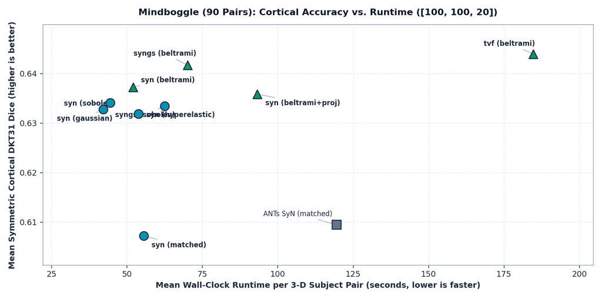

Figure 1: Accuracy vs. Runtime Pareto Frontier (90 Completed Mindboggle Pairs, [100, 100, 20]).

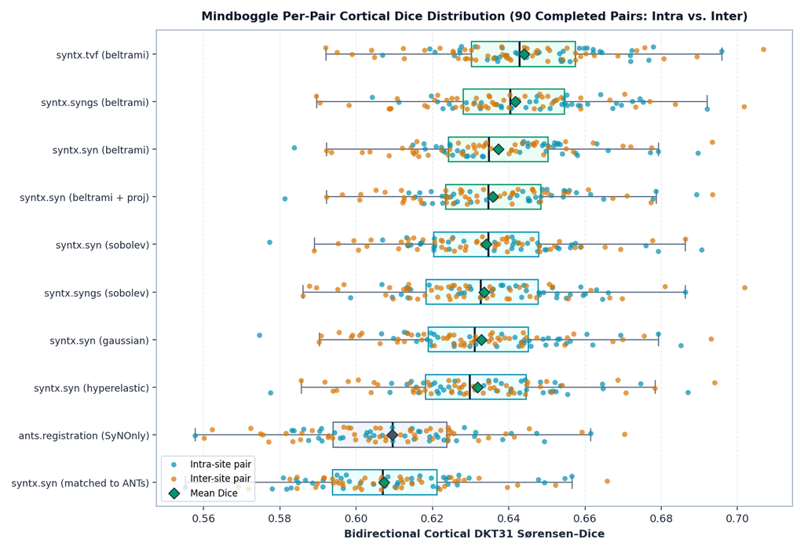

Figure 2: Per-Pair Cortical DKT31 Dice Distribution Across 90 Completed Pairs (Intra-Site vs. Inter-Site).

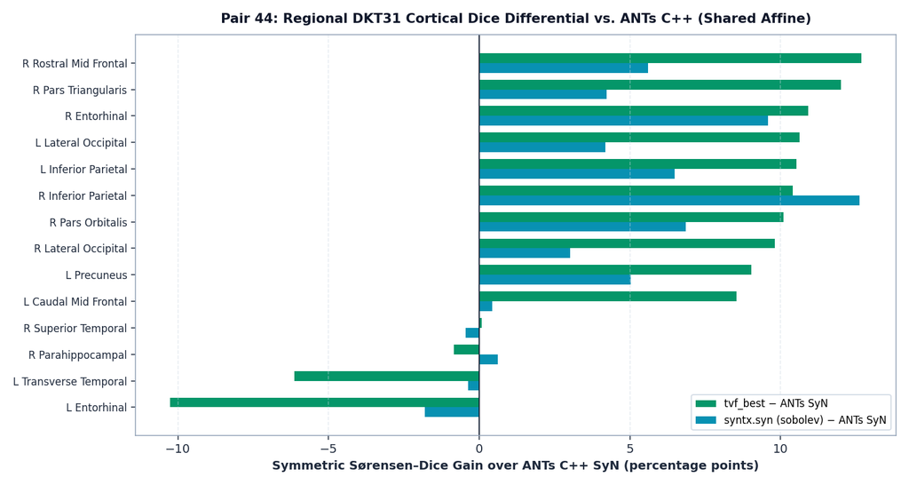

Figure 3: Pair 44 (mbhard) Per-Region DKT31 Cortical Symmetric Dice Gain over ANTs C++ SyN (Shared Affine).

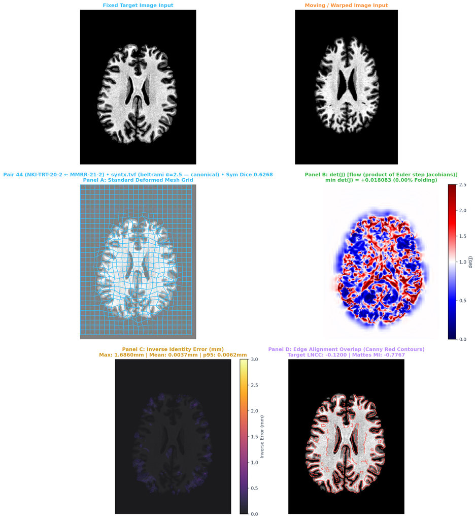

Figure 4: Pair 44 (mbhard) Standard 4-Panel QC — syntx.tvf Canonical Beltrami ([100, 100, 20], Shared Affine).

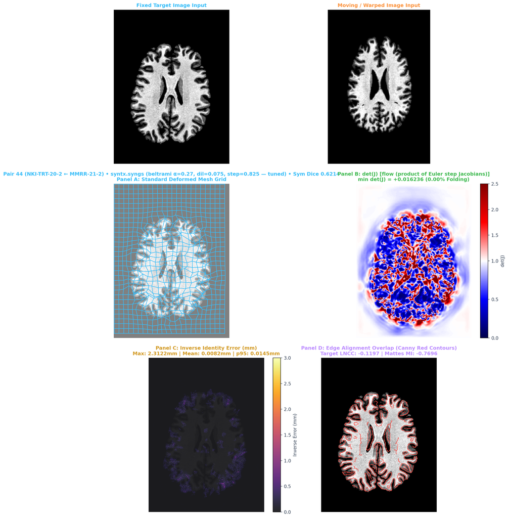

Figure 5: Pair 44 (mbhard) Standard 4-Panel QC — syntx.syngs Tuned Beltrami ([100, 100, 20], Shared Affine).

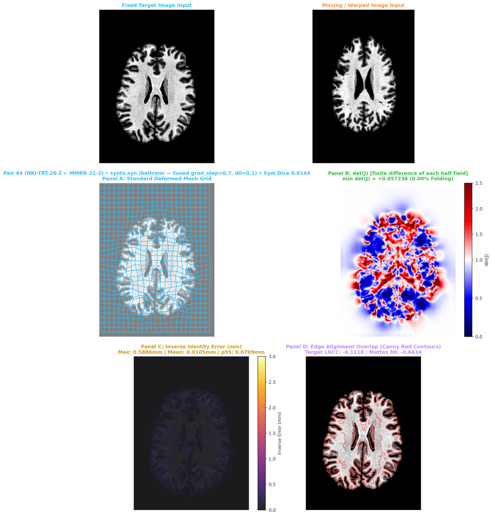

Figure 6: Pair 44 (mbhard) Standard 4-Panel QC — syntx.syn Tuned Beltrami ([100, 100, 20], Shared Affine).

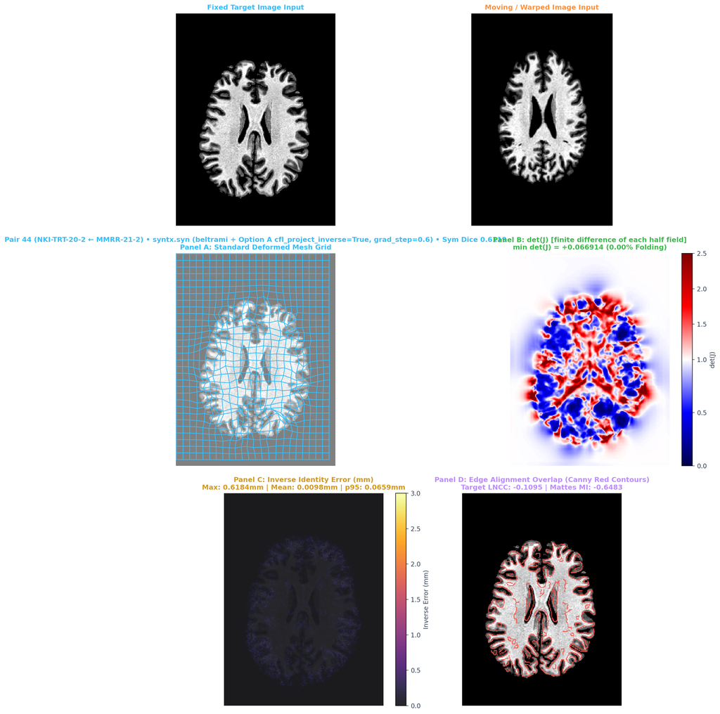

Figure 7: Pair 44 (mbhard) Standard 4-Panel QC — syntx.syn Tuned Beltrami + cfl_project_inverse=True ([100, 100, 20], Shared Affine).

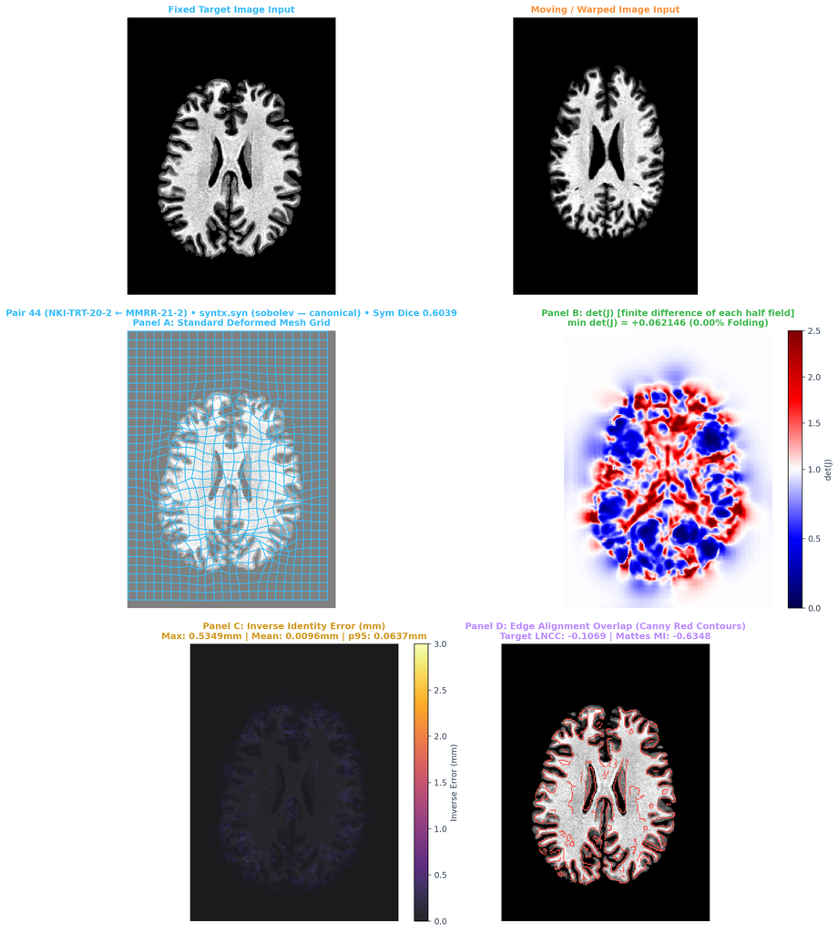

Figure 8: Pair 44 (mbhard) Standard 4-Panel QC — syntx.syn Canonical Sobolev ([100, 100, 20], Shared Affine).

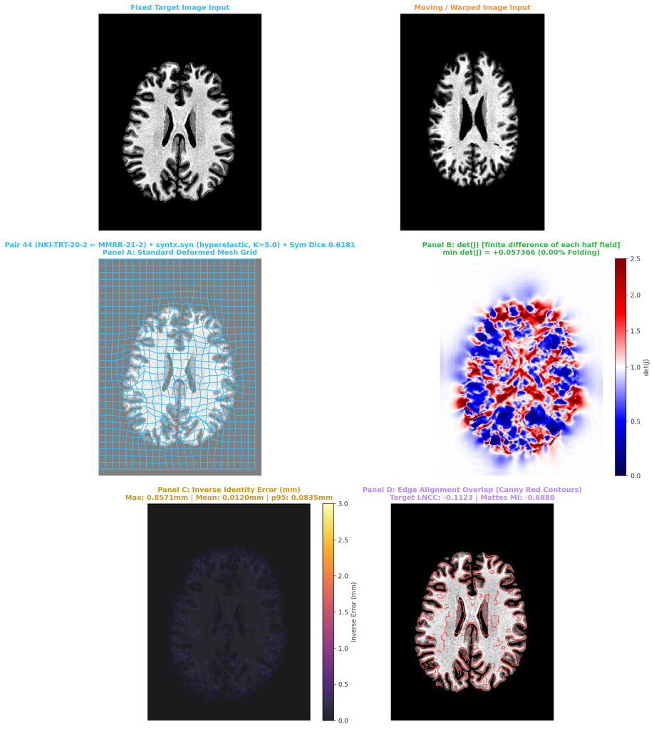

Figure 9: Pair 44 (mbhard) Standard 4-Panel QC — syntx.syn Continuum Hyperelastic ([100, 100, 20], Shared Affine).

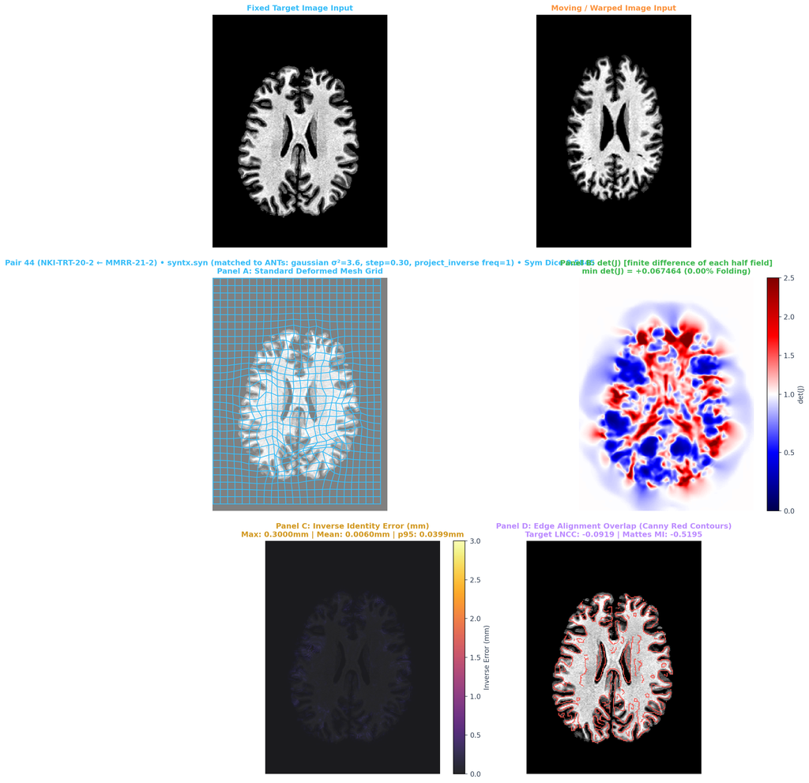

Figure 10: Pair 44 (mbhard) Standard 4-Panel QC — syntx.syn Matched to ANTs (gaussian σ²=3.6, step=0.30, project_inverse freq=1, Shared Affine).

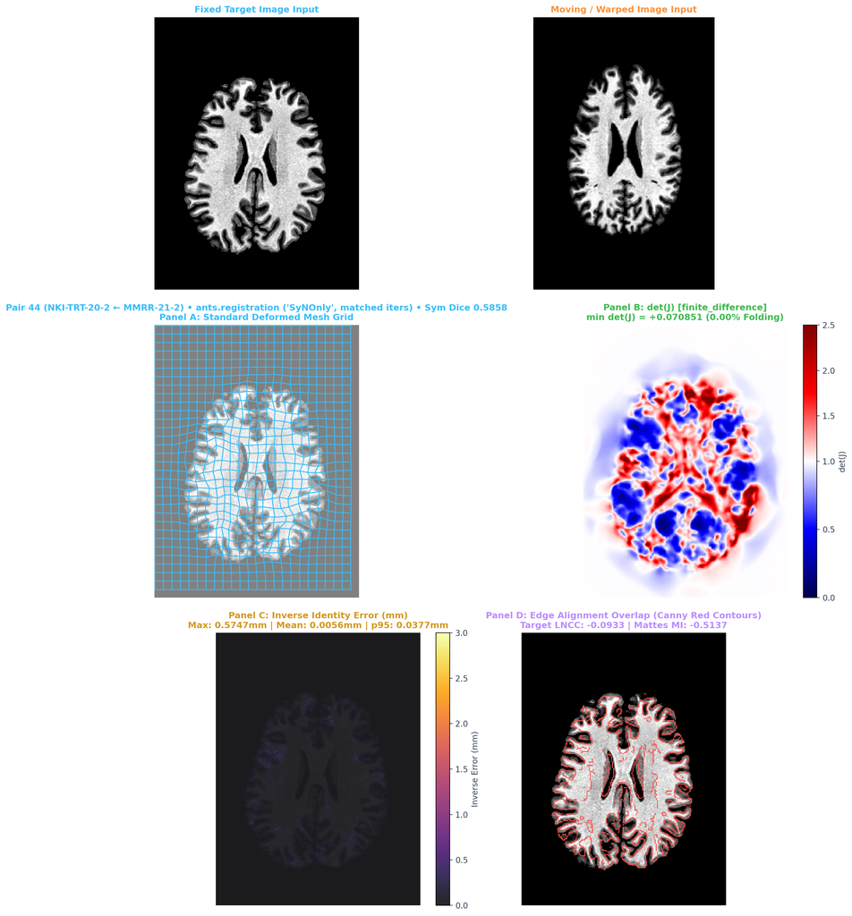

Figure 11: Pair 44 (mbhard) Standard 4-Panel QC — ANTs C++ SyNOnly ([100, 100, 20], Shared Affine).

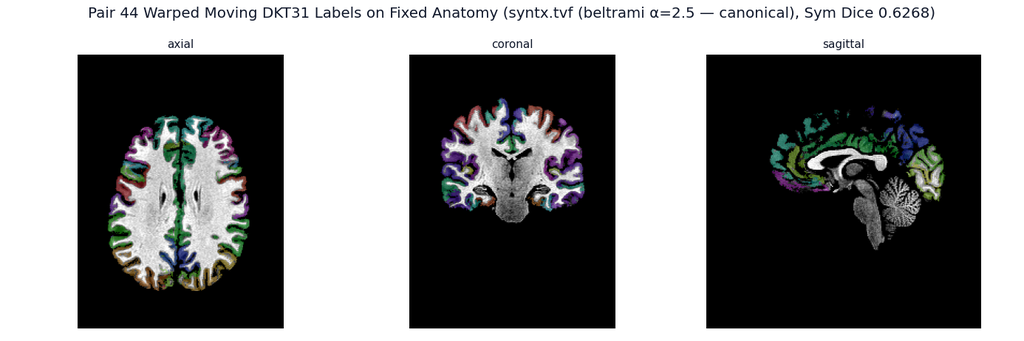

Figure 12: Pair 44 (mbhard) Warped Moving DKT31 Manual Cortical Parcellation Overlaid on Fixed Brain.

## Per-Pair Granular Results & `antsxqc` Verdicts

| Track | Pair | Arm | Sym Dice (Fix / Mov) | Fold % | Min \|J\| | ICE Mean / P95 (mm) | Time | antsxqc |
| --- | --- | --- | --- | --- | --- | --- | --- | --- |
| `affine` | **#00** (intra) OASIS-TRT-20-17 ← OASIS-TRT-20-16 | `ants_affine` | **0.3604** (0.3604 / 0.3603) | 0.00000% | +1.0000 | 0.0000 / 0.0000 | 3.4s | not_assessable |
| `affine` | **#00** (intra) OASIS-TRT-20-17 ← OASIS-TRT-20-16 | `syntx_affine_default` | **0.3649** (0.3649 / 0.3648) | 0.00000% | +1.0000 | 0.0000 / 0.0000 | 6.4s | not_assessable |
| `affine` | **#01** (intra) OASIS-TRT-20-16 ← OASIS-TRT-20-17 | `ants_affine` | **0.3517** (0.3517 / 0.3516) | 0.00000% | +1.0000 | 0.0000 / 0.0000 | 2.7s | not_assessable |
| `affine` | **#01** (intra) OASIS-TRT-20-16 ← OASIS-TRT-20-17 | `syntx_affine_default` | **0.3515** (0.3511 / 0.3518) | 0.00000% | +1.0000 | 0.0000 / 0.0000 | 6.4s | not_assessable |
| `affine` | **#02** (intra) NKI-TRT-20-10 ← NKI-TRT-20-4 | `ants_affine` | **0.3454** (0.3458 / 0.3451) | 0.00000% | +1.0000 | 0.0000 / 0.0000 | 3.3s | not_assessable |
| `affine` | **#02** (intra) NKI-TRT-20-10 ← NKI-TRT-20-4 | `syntx_affine_default` | **0.3566** (0.3569 / 0.3563) | 0.00000% | +1.0000 | 0.0000 / 0.0000 | 7.6s | not_assessable |
| `affine` | **#03** (intra) NKI-TRT-20-8 ← NKI-TRT-20-15 | `ants_affine` | **0.3692** (0.3689 / 0.3694) | 0.00000% | +1.0000 | 0.0000 / 0.0000 | 3.8s | not_assessable |
| `affine` | **#03** (intra) NKI-TRT-20-8 ← NKI-TRT-20-15 | `syntx_affine_default` | **0.3664** (0.3663 / 0.3666) | 0.00000% | +1.0000 | 0.0000 / 0.0000 | 7.5s | not_assessable |
| `affine` | **#04** (intra) OASIS-TRT-20-12 ← OASIS-TRT-20-1 | `ants_affine` | **0.3417** (0.3416 / 0.3418) | 0.00000% | +1.0000 | 0.0000 / 0.0000 | 3.3s | not_assessable |
| `affine` | **#04** (intra) OASIS-TRT-20-12 ← OASIS-TRT-20-1 | `syntx_affine_default` | **0.3440** (0.3442 / 0.3439) | 0.00000% | +1.0000 | 0.0000 / 0.0000 | 6.6s | not_assessable |
| `affine` | **#05** (intra) NKI-TRT-20-20 ← NKI-TRT-20-11 | `ants_affine` | **0.3200** (0.3200 / 0.3200) | 0.00000% | +1.0000 | 0.0000 / 0.0000 | 3.8s | not_assessable |
| `affine` | **#05** (intra) NKI-TRT-20-20 ← NKI-TRT-20-11 | `syntx_affine_default` | **0.3186** (0.3188 / 0.3184) | 0.00000% | +1.0000 | 0.0000 / 0.0000 | 7.6s | not_assessable |
| `affine` | **#06** (intra) MMRR-21-17 ← MMRR-21-3 | `ants_affine` | **0.3056** (0.3058 / 0.3054) | 0.00000% | +1.0000 | 0.0000 / 0.0000 | 3.5s | not_assessable |
| `affine` | **#06** (intra) MMRR-21-17 ← MMRR-21-3 | `syntx_affine_default` | **0.3116** (0.3117 / 0.3115) | 0.00000% | +1.0000 | 0.0000 / 0.0000 | 7.9s | not_assessable |
| `affine` | **#07** (intra) MMRR-21-12 ← MMRR-21-20 | `ants_affine` | **0.3158** (0.3160 / 0.3156) | 0.00000% | +1.0000 | 0.0000 / 0.0000 | 2.8s | not_assessable |
| `affine` | **#07** (intra) MMRR-21-12 ← MMRR-21-20 | `syntx_affine_default` | **0.3131** (0.3132 / 0.3129) | 0.00000% | +1.0000 | 0.0000 / 0.0000 | 7.7s | not_assessable |
| `affine` | **#08** (intra) MMRR-21-8 ← MMRR-21-14 | `ants_affine` | **0.3711** (0.3708 / 0.3714) | 0.00000% | +1.0000 | 0.0000 / 0.0000 | 3.2s | not_assessable |
| `affine` | **#08** (intra) MMRR-21-8 ← MMRR-21-14 | `syntx_affine_default` | **0.3715** (0.3719 / 0.3710) | 0.00000% | +1.0000 | 0.0000 / 0.0000 | 8.0s | not_assessable |
| `affine` | **#09** (intra) OASIS-TRT-20-3 ← OASIS-TRT-20-10 | `ants_affine` | **0.3436** (0.3436 / 0.3436) | 0.00000% | +1.0000 | 0.0000 / 0.0000 | 2.9s | not_assessable |
| `affine` | **#09** (intra) OASIS-TRT-20-3 ← OASIS-TRT-20-10 | `syntx_affine_default` | **0.3395** (0.3395 / 0.3395) | 0.00000% | +1.0000 | 0.0000 / 0.0000 | 6.6s | not_assessable |
| `affine` | **#10** (intra) NKI-TRT-20-11 ← NKI-TRT-20-10 | `ants_affine` | **0.3503** (0.3499 / 0.3507) | 0.00000% | +1.0000 | 0.0000 / 0.0000 | 3.8s | not_assessable |
| `affine` | **#10** (intra) NKI-TRT-20-11 ← NKI-TRT-20-10 | `syntx_affine_default` | **0.3453** (0.3449 / 0.3456) | 0.00000% | +1.0000 | 0.0000 / 0.0000 | 7.5s | not_assessable |
| `affine` | **#11** (intra) NKI-RS-22-17 ← NKI-RS-22-1 | `ants_affine` | **0.3486** (0.3488 / 0.3485) | 0.00000% | +1.0000 | 0.0000 / 0.0000 | 4.2s | not_assessable |
| `affine` | **#11** (intra) NKI-RS-22-17 ← NKI-RS-22-1 | `syntx_affine_default` | **0.3521** (0.3518 / 0.3523) | 0.00000% | +1.0000 | 0.0000 / 0.0000 | 7.4s | not_assessable |
| `affine` | **#12** (intra) MMRR-21-9 ← MMRR-21-2 | `ants_affine` | **0.3365** (0.3373 / 0.3358) | 0.00000% | +1.0000 | 0.0000 / 0.0000 | 3.4s | not_assessable |
| `affine` | **#12** (intra) MMRR-21-9 ← MMRR-21-2 | `syntx_affine_default` | **0.3330** (0.3330 / 0.3330) | 0.00000% | +1.0000 | 0.0000 / 0.0000 | 7.7s | not_assessable |
| `affine` | **#13** (intra) OASIS-TRT-20-7 ← OASIS-TRT-20-15 | `ants_affine` | **0.3218** (0.3218 / 0.3218) | 0.00000% | +1.0000 | 0.0000 / 0.0000 | 3.3s | not_assessable |
| `affine` | **#13** (intra) OASIS-TRT-20-7 ← OASIS-TRT-20-15 | `syntx_affine_default` | **0.3230** (0.3229 / 0.3230) | 0.00000% | +1.0000 | 0.0000 / 0.0000 | 6.4s | not_assessable |
| `affine` | **#14** (intra) NKI-RS-22-21 ← NKI-RS-22-2 | `ants_affine` | **0.3655** (0.3658 / 0.3652) | 0.00000% | +1.0000 | 0.0000 / 0.0000 | 3.6s | not_assessable |
| `affine` | **#14** (intra) NKI-RS-22-21 ← NKI-RS-22-2 | `syntx_affine_default` | **0.3678** (0.3676 / 0.3680) | 0.00000% | +1.0000 | 0.0000 / 0.0000 | 7.3s | not_assessable |

[output cut: 1050 more lines]